# Using Raster Data in R

## 12.2 Prediction

As with the function `interpolate`, the function `predict` also returns a raster object with spatial predictions and has as inputs a raster object and a model object. However, these are different than in the function ‘interpolate’:

- *Raster object*: is typically a multi-layer raster (i.e. RasterStack or RasterBrick)
- *Model object*: is a model of any class that has a ‘predict’ method, including: glm, gam, randomForest, and is fitted to raster data.

This approach of predicting from a fitted model to raster data is commonly used in remote sensing (e.g. for the classification of satellite images) and in ecology (e.g. for species distribution modelling).

For further informatin see help pages for [the predict function in the package raster](http://127.0.0.1:25588/library/raster/html/predict.html) and the package [dismo](http://127.0.0.1:25588/library/dismo/html/dismo-package.html).

```r
# Temperature Raster: With Gradient from West to East.
temp.ras = raster(nrow=10, ncol=16)
temp.ras[] = colFromCell(temp.ras,1:ncell(temp.ras))*10/4 + rnorm(ncell(temp.ras),sd=1)
temp.ras
```

```
## class       : RasterLayer
## dimensions  : 10, 16, 160  (nrow, ncol, ncell)
## resolution  : 22.5, 18  (x, y)
## extent      : -180, 180, -90, 90  (xmin, xmax, ymin, ymax)
## coord. ref. : +proj=longlat +datum=WGS84 +ellps=WGS84 +towgs84=0,0,0
## data source : in memory
## names       : layer
## values      : 1.040944, 41.48178  (min, max)
```

```r
# Humidity Raster: With Gradient from North to South.
humid.ras = raster(nrow=10, ncol=16)
humid.ras[] = 20 + rowFromCell(humid.ras,1:ncell(humid.ras)) * 7.5 + rnorm(ncell(humid.ras),sd=2)
humid.ras
```

```
## class       : RasterLayer
## dimensions  : 10, 16, 160  (nrow, ncol, ncell)
## resolution  : 22.5, 18  (x, y)
## extent      : -180, 180, -90, 90  (xmin, xmax, ymin, ymax)
## coord. ref. : +proj=longlat +datum=WGS84 +ellps=WGS84 +towgs84=0,0,0
## data source : in memory
## names       : layer
## values      : 23.46588, 98.61089  (min, max)
```

```r
# Create a RasterBrick object with Environmental Conditions (Temperature & Humidity)
EnvCond.brick = brick(temp.ras,humid.ras)
names(EnvCond.brick) = c("Temperature","Humidity")
EnvCond.brick
```

```
## class       : RasterBrick
## dimensions  : 10, 16, 160, 2  (nrow, ncol, ncell, nlayers)
## resolution  : 22.5, 18  (x, y)
## extent      : -180, 180, -90, 90  (xmin, xmax, ymin, ymax)
## coord. ref. : +proj=longlat +datum=WGS84 +ellps=WGS84 +towgs84=0,0,0
## data source : in memory
## names       : Temperature,  Humidity
## min values  :    1.040944, 23.465881
## max values  :    41.48178,  98.61089
```

```r
# Presence & Absence Cells
  # Present: High Temp & High Humidity
p = cbind(floor(runif(15,min=7,max=11)),floor(runif(15,min=9,max=17)))
  # Absent: 1-5: Low Temp & Low Humidity; 6-10: Low Temp & High Humidity; 11-15: High Temp & Low Humidity
a = cbind( floor(c(runif(10,min=1,max=6),runif(5,min=6,max=11))),
           floor(c(runif(5,min=1,max=9),runif(5,min=9,max=17),runif(5,min=1,max=9))) )

# Presence/Absece Raster (for Visualization)
pa.ras = raster(nrow=10, ncol=16)
pa.ras[] = NA
pa.ras[p] = 1
pa.ras[a] = 0
pa.ras
```

```
## class       : RasterLayer
## dimensions  : 10, 16, 160  (nrow, ncol, ncell)
## resolution  : 22.5, 18  (x, y)
## extent      : -180, 180, -90, 90  (xmin, xmax, ymin, ymax)
## coord. ref. : +proj=longlat +datum=WGS84 +ellps=WGS84 +towgs84=0,0,0
## data source : in memory
## names       : layer
## values      : 0, 1  (min, max)
```

```r
pa.ras[]
```

```
##   [1]  0 NA NA NA NA  0 NA NA NA NA NA NA NA NA NA NA  0 NA NA NA NA NA NA
##  [24] NA NA NA NA NA NA NA NA NA NA NA NA NA NA NA NA NA  0 NA NA NA NA NA
##  [47] NA NA NA NA NA NA NA NA NA NA NA NA  0 NA NA NA NA NA  0 NA NA NA NA
##  [70] NA NA NA NA NA NA  0 NA  0 NA  0 NA NA  0 NA NA  0  0 NA NA NA NA NA
##  [93] NA NA NA NA NA NA NA NA NA NA NA NA NA NA NA  1 NA NA NA NA NA NA NA
## [116] NA NA NA NA NA  1 NA NA  1 NA NA  1 NA NA NA NA  0 NA NA NA NA  1 NA
## [139]  1  1  1 NA NA  1 NA NA NA NA NA  0 NA NA  1  1 NA  1 NA NA NA NA
```

```r
# Plot Rasters
par(mfrow=c(2,2))
plot(temp.ras, main="Temperature (Â°C): Longitudinal gradient")
plot(humid.ras, main="Humidity (%): Latitudinal gradient")
plot(pa.ras, main="Presence & Absences for Training")

# Extract Values for Pints
pa.xy = rbind(cbind(1,p), cbind(0,a))
pa.xy
```

```
##       [,1] [,2] [,3]
##  [1,]    1    8    9
##  [2,]    1    8   12
##  [3,]    1    9   12
##  [4,]    1    9   13
##  [5,]    1   10    9
##  [6,]    1    9   16
##  [7,]    1   10   10
##  [8,]    1    8   15
##  [9,]    1    9   12
## [10,]    1    7   12
## [11,]    1    8   12
## [12,]    1    8   12
## [13,]    1    9   11
## [14,]    1   10   12
```

[output cut: 16 more lines]

```r
cells.indices = cellFromRowCol(EnvCond.brick, rownr=pa.xy[,2], colnr=pa.xy[,3])
pa.envcond.df = data.frame(cbind(pa=pa.xy[,1], extract(EnvCond.brick, cells.indices)))
#pa.envcond.df = data.frame(cbind(pa=pa.xy[,1], extract(EnvCond.brick, pa.xy[,2:3])))
pa.envcond.df
```

```
##    pa Temperature Humidity
## 1   1   22.046788 80.15854
## 2   1   29.207360 81.16388
## 3   1   28.116552 87.62152
## 4   1   32.183719 85.89127
## 5   1   23.318033 96.10167
## 6   1   40.939479 87.35237
## 7   1   24.989484 93.84765
## 8   1   36.722463 80.21980
## 9   1   28.116552 87.62152
## 10  1   28.899386 71.85999
## 11  1   29.207360 81.16388
## 12  1   29.207360 81.16388
## 13  1   25.277540 85.76766
## 14  1   30.339649 93.86888
```

[output cut: 16 more lines]

```r
# Fit Model (GLM)
glm.fit = glm(formula=pa~., data=pa.envcond.df)
summary(glm.fit)
```

```
##
## Call:
## glm(formula = pa ~ ., data = pa.envcond.df)
##
## Deviance Residuals:
##     Min       1Q   Median       3Q      Max
## -0.7541  -0.2684   0.1330   0.2504   0.3980
##
## Coefficients:
##              Estimate Std. Error t value Pr(>|t|)
## (Intercept) -0.839523   0.214695  -3.910 0.000561 ***
## Temperature  0.012751   0.006284   2.029 0.052429 .
## Humidity     0.014933   0.003248   4.598 8.97e-05 ***
## ---
## Signif. codes:  0 '***' 0.001 '**' 0.01 '*' 0.05 '.' 0.1 ' ' 1
##
## (Dispersion parameter for gaussian family taken to be 0.107324)
##
##     Null deviance: 7.5000  on 29  degrees of freedom
## Residual deviance: 2.8977  on 27  degrees of freedom
## AIC: 23.018
##
## Number of Fisher Scoring iterations: 2
```

```r
# Predict to a Raster
pred.ras = predict(EnvCond.brick, glm.fit, progress='text')
pred.ras
```

```
## class       : RasterLayer
## dimensions  : 10, 16, 160  (nrow, ncol, ncell)
## resolution  : 22.5, 18  (x, y)
## extent      : -180, 180, -90, 90  (xmin, xmax, ymin, ymax)
## coord. ref. : +proj=longlat +datum=WGS84 +ellps=WGS84 +towgs84=0,0,0
## data source : in memory
## names       : layer
## values      : -0.3616076, 1.076894  (min, max)
```

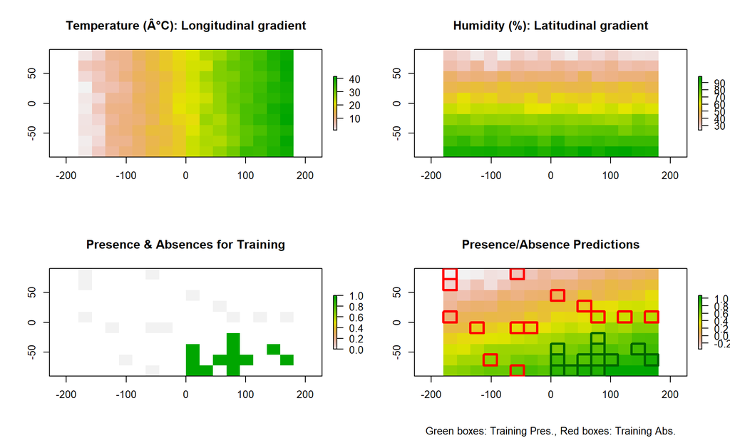

```r
# Plot Predictions & PA Points
plot(pred.ras, main="Presence/Absence Predictions",
     sub="Green boxes: Training Pres., Red boxes: Training Abs.")
p.rc = rowColFromCell(pred.ras, cells.indices[1:15])
a.rc = rowColFromCell(pred.ras, cells.indices[16:30])
#p.rc; a.rc
for( cnt in 1:15 ) {
    plot(extent(pred.ras, p.rc[cnt,1], p.rc[cnt,1], p.rc[cnt,2], p.rc[cnt,2]), add=TRUE, col='darkgreen', lwd=3)
    plot(extent(pred.ras, a.rc[cnt,1], a.rc[cnt,1], a.rc[cnt,2], a.rc[cnt,2]), add=TRUE, col='red', lwd=3)
}
```

# 13 Other GIS operations with rasters in R

First we create a dataset with simulated elevation values to be used in this section.

```r
# rb2 created above (see 'Visualising Rasters') contains Latitudinal and Longitudinal gradients,
# with the former 3 times stronger.
r2b[]
```

```
##   [1] -0.39524360  2.66384294  3.99954580  4.16745679  5.24988026
##   [6]  0.40589315 14.30651973  4.04091835 16.92986168 16.77818836
##  [11] 15.88233646 14.68644886  9.80848040 17.79975006  0.09885152
##  [16]  8.78180736 10.60200546 12.80048936 18.42631733 19.93899239
##  [21]  2.98455584 10.21879499 15.83377606 11.08843678  2.67961229
##  [26] 25.97203594  3.56009869 26.38698756 12.01518560 20.87927482
##  [31] 10.14196183 17.46669274 11.99108315 12.56389331 18.43483351
##  [36]  9.93879763 18.98364432 14.12359146 30.63319358 24.77790145
##  [41] 18.92852131 18.54557685 20.67532531 18.84050075 15.27813125
##  [46] 22.45902285 21.52867981 28.72469832 27.04850185 28.48428457
##  [51] 19.80453669 22.88693760 14.00985039 23.21223542 21.75694613
##  [56] 27.83304516 30.00598866 18.75878709 40.48881255 31.05118435
##  [61] 24.84470512 23.42887645 32.15939932 23.87903442 19.86098577
##  [66] 19.13839534 25.97409788 36.78779110 20.99483445 27.89430383
##  [71] 31.60503432 38.54758761 25.70845351 20.37394410 30.36158823
##  [76] 28.82325630 38.59897664 34.31546249 27.38482744 33.49720401
##  [81] 33.55508396 35.96804694 27.23710598 36.58418695 22.84339190
##  [86] 37.80581194 28.16133673 32.23569782 28.39875243 36.56078188
##  [91] 30.75474096 36.49371058 27.71873859 31.58793704 36.26023793
##  [96] 39.36957711 42.14387837 41.58466967 34.72312654 36.31295396
```

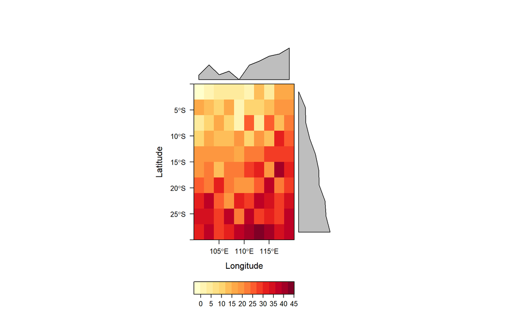

```r
levelplot(r2b, par.settings=YlOrRdTheme)
```

```r
# Making all values positive and stretched out by 10 (to recreate some decent 'elevation')
r2b.elev = (r2b + abs(cellStats(r2b, min)) + 0.1) * 10
r2b.elev[]
```

```
##   [1]   1.000000  31.590865  44.947894  46.627004  57.451239   9.011367
##   [7] 148.017633  45.361620 174.251053 172.734320 163.775801 151.816925
##  [13] 103.037240 182.949937   5.940951  92.770510 110.972491 132.957330
##  [19] 189.215609 204.342360  34.797994 107.140386 163.290197 115.836804
##  [25]  31.748559 264.672795  40.553423 268.822312 125.104292 213.745184
##  [31] 106.372054 179.619363 124.863268 130.591369 189.300771 104.340412
##  [37] 194.788879 146.188351 311.284372 252.731450 194.237649 190.408204
##  [43] 211.705689 193.357444 157.733748 229.542665 220.239234 292.199419
##  [49] 275.437455 289.795282 202.997803 233.821812 145.050940 237.074790
##  [55] 222.521897 283.282888 305.012323 192.540307 409.840561 315.464280
##  [61] 253.399487 239.241200 326.546429 243.742780 203.562294 196.336389
##  [67] 264.693415 372.830347 214.900780 283.895474 321.002779 390.428312
##  [73] 262.036971 208.691877 308.568318 293.184999 390.942202 348.107061
##  [79] 278.800710 339.924476 340.503276 364.632905 277.323496 370.794305
##  [85] 233.386355 383.010555 286.565803 327.309414 288.939960 370.560255
##  [91] 312.499846 369.889542 282.139822 320.831806 367.554815 398.648207
##  [97] 426.391220 420.799133 352.183701 368.081976
```

```r
cellStats(r2b.elev, min)
```

```
## [1] 1
```